# Pemodelan dan Diagnostik Model ARIMA (Tugas Praktikum Minggu 6 dan 7)

Nazuwa Aulia

2023-10-15

# Packages yang digunakan

```r
library(ggplot2)
library(tsibble)
library(tseries)
library(MASS)
library(forecast)
library(TSA)
library(TTR)
library(aTSA)
library(graphics)
library(rio)
```

# Import Data

```r
data <- import("https://raw.githubusercontent.com/nazuwaaulia/MPDW/main/Pertemuan%201/dataset.csv")
data
```

```
##               date rate
## 1        Juli 2013  7.3
## 2     Agustus 2013  7.2
## 3   September 2013  7.2
## 4     Oktober 2013  7.2
## 5    November 2013  6.9
## 6    Desember 2013  6.7
## 7     Januari 2014  6.6
## 8    Februari 2014  6.7
## 9       Maret 2014  6.7
## 10      April 2014  6.2
## 11        Mei 2014  6.3
## 12       Juni 2014  6.1
## 13       Juli 2014  6.2
## 14    Agustus 2014  6.1
```

[output cut: 107 more lines]

```r
data.ts<-ts(data$rate)
```

## Eksplorasi Data

### Plot Data Penuh

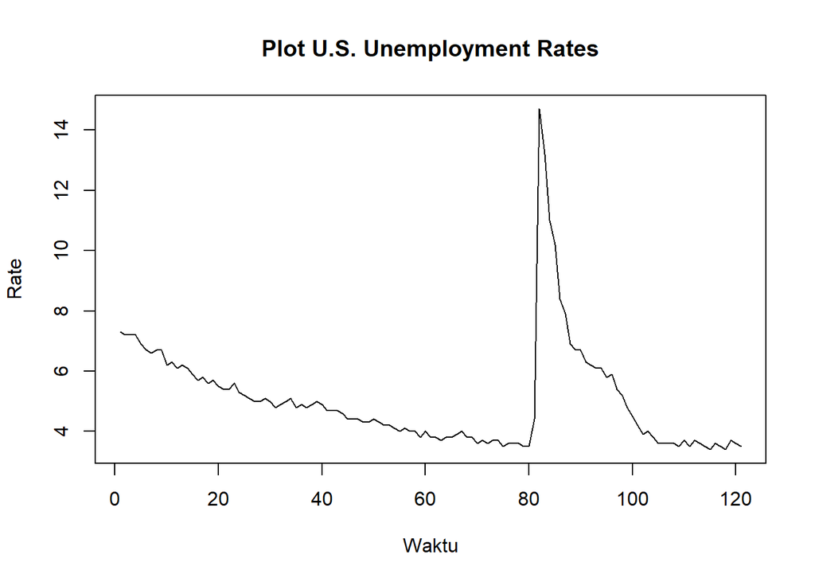

```r
plot.ts(data.ts, lty=1, xlab="Waktu", ylab="Rate", main="Plot U.S. Unemployment Rates")
```

Berdasarkan plot data deret waktu diatas, terlihat bahwa data cenderung memiliki trend yang turun. Berdasarkan pola data, pembagian data latih dan data uji ditetapkan dengan proporsi 80%:20%.

### Plot Data Latih

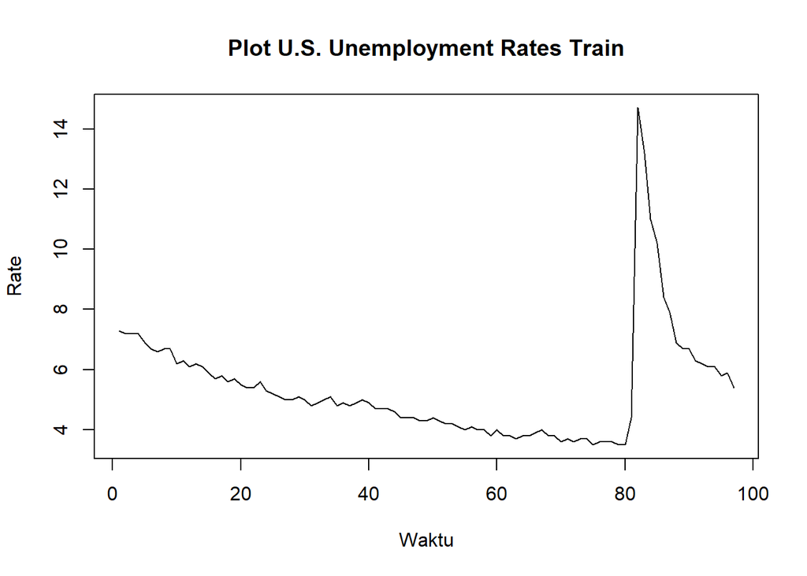

```r
data.train<-data[1:97,]
train.ts<-ts(data.train$rate)
plot.ts(train.ts, lty=1, xlab="Waktu", ylab="Rate", main="Plot U.S. Unemployment Rates Train")
```

Berdasarkan plot data deret waktu pada data latih, terlihat bahwa data cenderung memiliki trend yang turun dan cenderung tidak bergerak pada nilai tengah tertentu. Hal tersebut mengindikasikan bahwa data tidak stasioner dalam rataan.

### Plot Data Uji

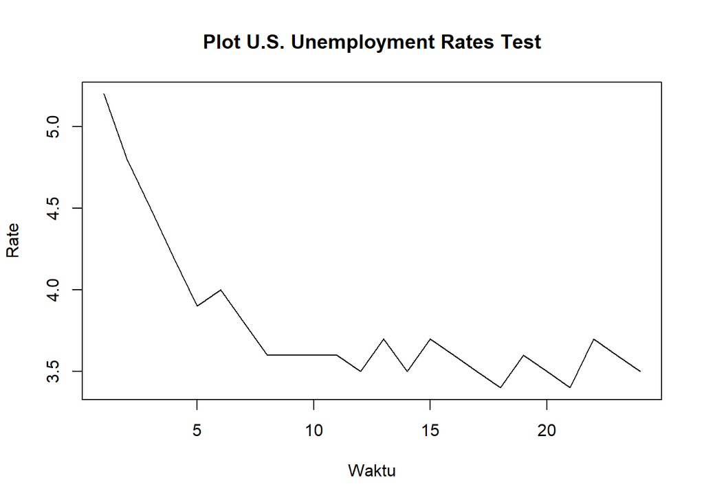

```r
data.test<-data[98:121,]
test.ts<-ts(data.test$rate)
plot.ts(test.ts, lty=1, xlab="Waktu", ylab="Rate", main="Plot U.S. Unemployment Rates Test")
```

Berdasarkan plot data deret waktu pada data uji, terlihat bahwa data cenderung memiliki trend yang turun dan cenderung tidak bergerak pada nilai tengah tertentu. Hal tersebut mengindikasikan bahwa data tidak stasioner dalam rataan.

## Uji Stasioneritas Data

### Plot ACF

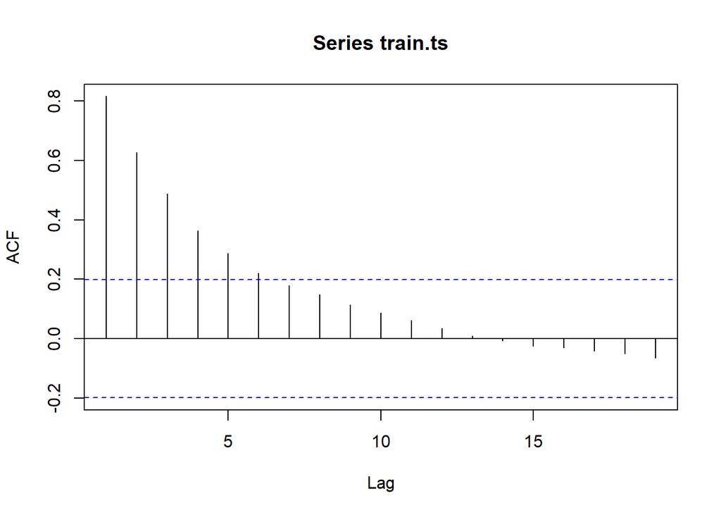

```r
acf(train.ts)
```

### Uji ADF

```r
tseries::adf.test(train.ts)
```

```
##
##  Augmented Dickey-Fuller Test
##
## data:  train.ts
## Dickey-Fuller = -2.6982, Lag order = 4, p-value = 0.2878
## alternative hypothesis: stationary
```

*Hipotesis :*

$H_0$ : Data tidak stasioner dalam rataan

$H_1$ : Data stasioner dalam rataan

Berdasarkan uji ADF tersebut, didapat *p-value* sebesar 0.2878 > 0.05 sehingga tak tolak $H_0$ pada taraf nyata 5% dan menandakan bahwa data tidak stasioner dalam rataan. Hal ini sesuai dengan hasil eksplorasi menggunakan plot time series dan plot ACF, sehingga ketidakstasioneran model harus ditangani

### Plot Box-Cox

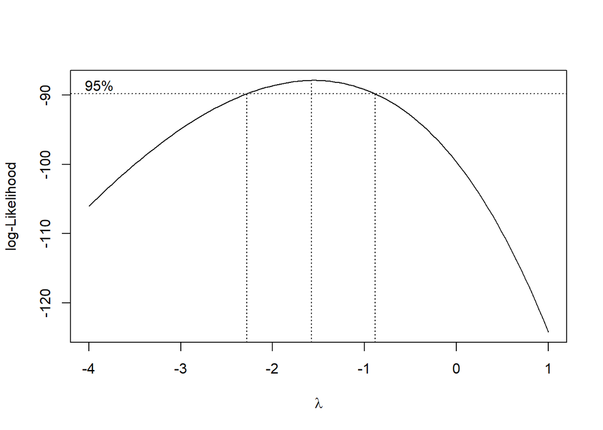

```r
index <- seq(1:97)
bc = boxcox(train.ts~index, lambda = seq(-4,1,by=1))
```

```r
#Nilai Rounded Lambda
lambda <- bc$x[which.max(bc$y)]
lambda
```

```
## [1] -1.575758
```

```r
#SK
bc$x[bc$y > max(bc$y) - 1/2 * qchisq(.95,1)]
```

```
##  [1] -2.2323232 -2.1818182 -2.1313131 -2.0808081 -2.0303030 -1.9797980
##  [7] -1.9292929 -1.8787879 -1.8282828 -1.7777778 -1.7272727 -1.6767677
## [13] -1.6262626 -1.5757576 -1.5252525 -1.4747475 -1.4242424 -1.3737374
## [19] -1.3232323 -1.2727273 -1.2222222 -1.1717172 -1.1212121 -1.0707071
## [25] -1.0202020 -0.9696970 -0.9191919
```

Plot Boxcox menunjukkan nilai *rounded value* ($\lambda$) optimum sebesar **-1.575758** dan pada selang kepercayaan 95% nilai memiliki batas bawah **-2.2323232** dan batas atas **-0.9191919**. Selang tersebut tidak memuat nilai satu sehingga dapat dikatakan bahwa data tidak stasioner dalam ragam.

## Penanganan Ketidakstasioneran Data Dalam Rataan

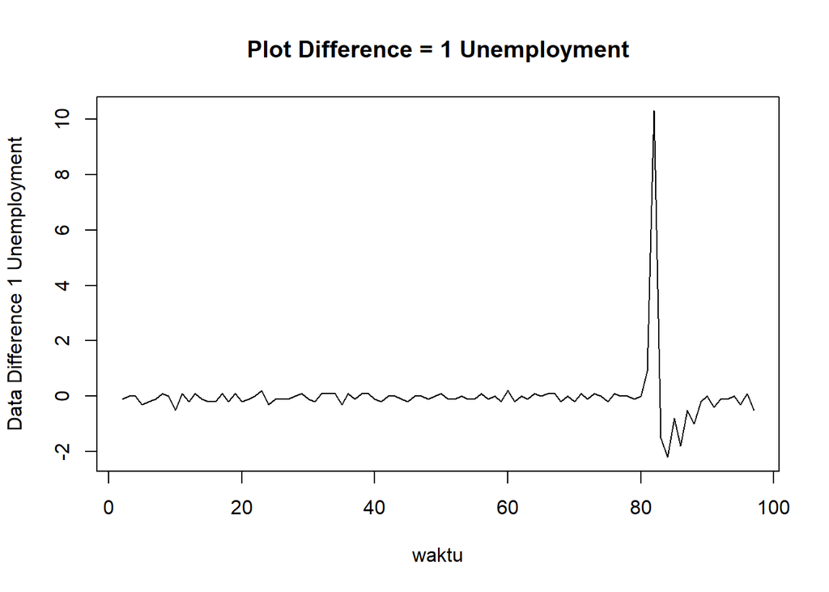

```r
train.diff<-diff(train.ts,differences = 1)
plot.ts(train.diff, lty=1, xlab="waktu", ylab="Data Difference 1 Unemployment", main="Plot Difference = 1 Unemployment")
```

Berdasarkan plot tersebut dapat dilihat bahwa data masih belum stasioner dalam rataan sehingga akan dilakukan differencing kembali untuk lebih membuat data stasioner dalam rataan

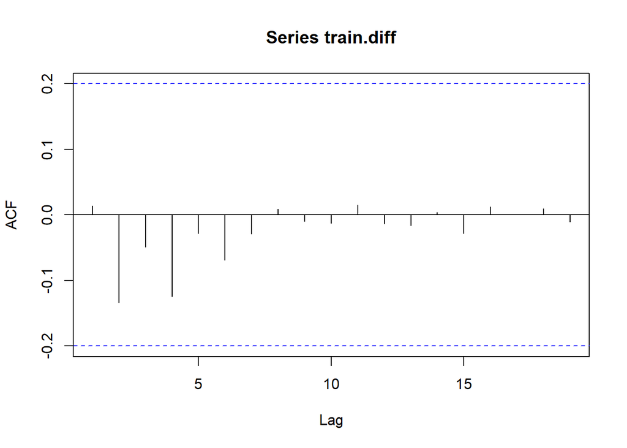

```r
acf(train.diff)
```

Berdasarkan plot ACF hasil dari differencing 1 dapat dilihat bahwa plot ACF tidak *cut-off* pada lag manapun dan tidak membentuk gelombang sinus

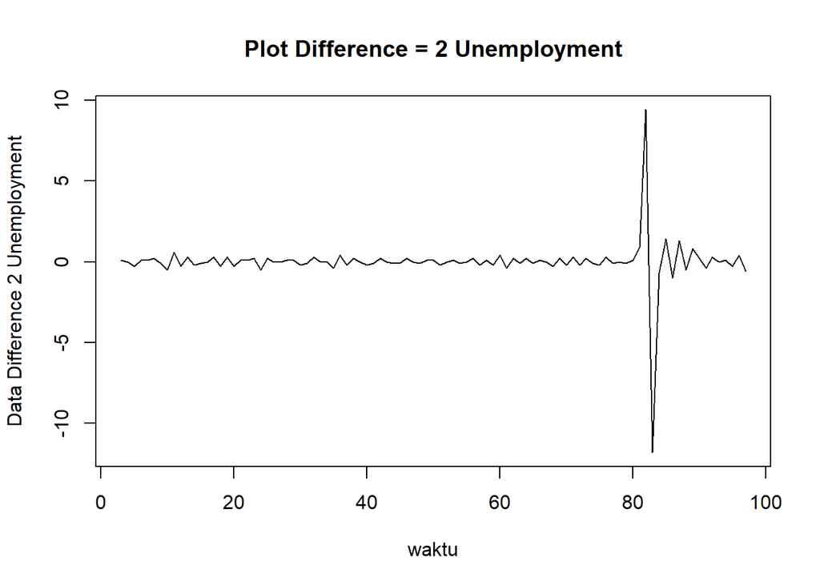

```r
train.diff2<-diff(train.ts,differences = 2)
plot.ts(train.diff2, lty=1, xlab="waktu", ylab="Data Difference 2 Unemployment", main="Plot Difference = 2 Unemployment")
```

Berdasarkan plot data deret waktu, terlihat bahwa data sudah stasioner dalam rataan ditandai dengan data bergerak pada nilai tengah tertentu

### Plot ACF

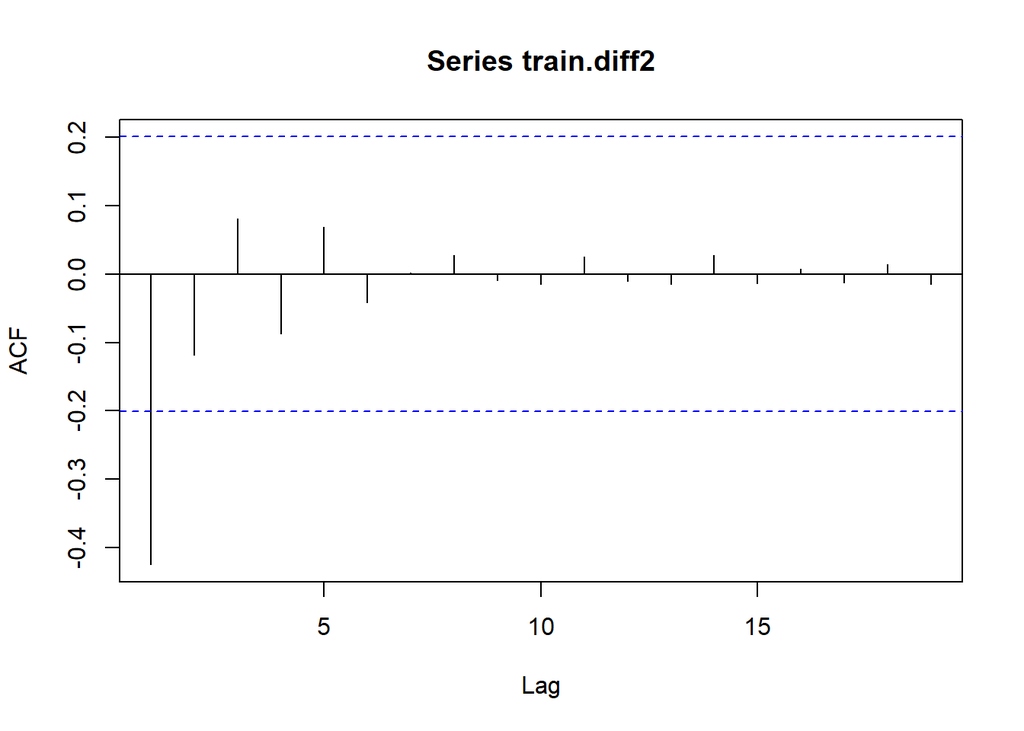

```r
acf(train.diff2)
```

Berdasarkan plot tersebut, terlihat bahwa plot ACF cuts off pada lag ke 1. Hal ini menandakan data sudah stasioner dalam rataan dan ketidakstasioneran data telah berhasil tertangani

### Uji ADF

```r
tseries::adf.test(train.diff2)
```

```
##
##  Augmented Dickey-Fuller Test
##
## data:  train.diff2
## Dickey-Fuller = -7.0797, Lag order = 4, p-value = 0.01
## alternative hypothesis: stationary
```

*Hipotesis :*

$H_0$ : Data tidak stasioner dalam rataan

$H_1$ : Data stasioner dalam rataan

Berdasarkan uji ADF tersebut, didapat *p-value* sebesar 0.01 < 0.05 sehingga tolak $H_0$ pada taraf nyata 5% atau data stasioner dalam rataan. Hal ini sesuai dengan hasil eksplorasi menggunakan plot time series dan plot ACF, sehingga dalam hal ini ketidakstasioneran data sudah berhasil ditangani dan dapat dilanjutkan ke pemodelan

## Identifikasi Model

### Plot ACF

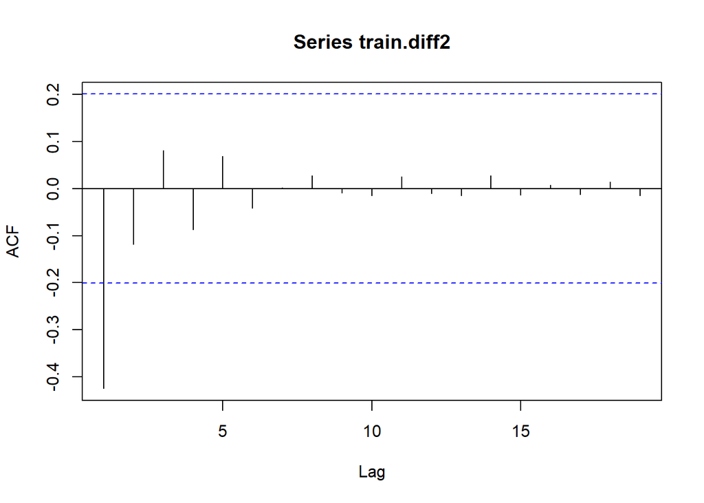

```r
acf(train.diff2)
```

Berdasarkan plot tersebut, terlihat bahwa plot ACF cenderung *cuts off* pada lag ke 1, sehingga jika plot PACF dianggap *tails of*, maka model tentatifnya adalah ARIMA(0,2,1).

### Plot PACF

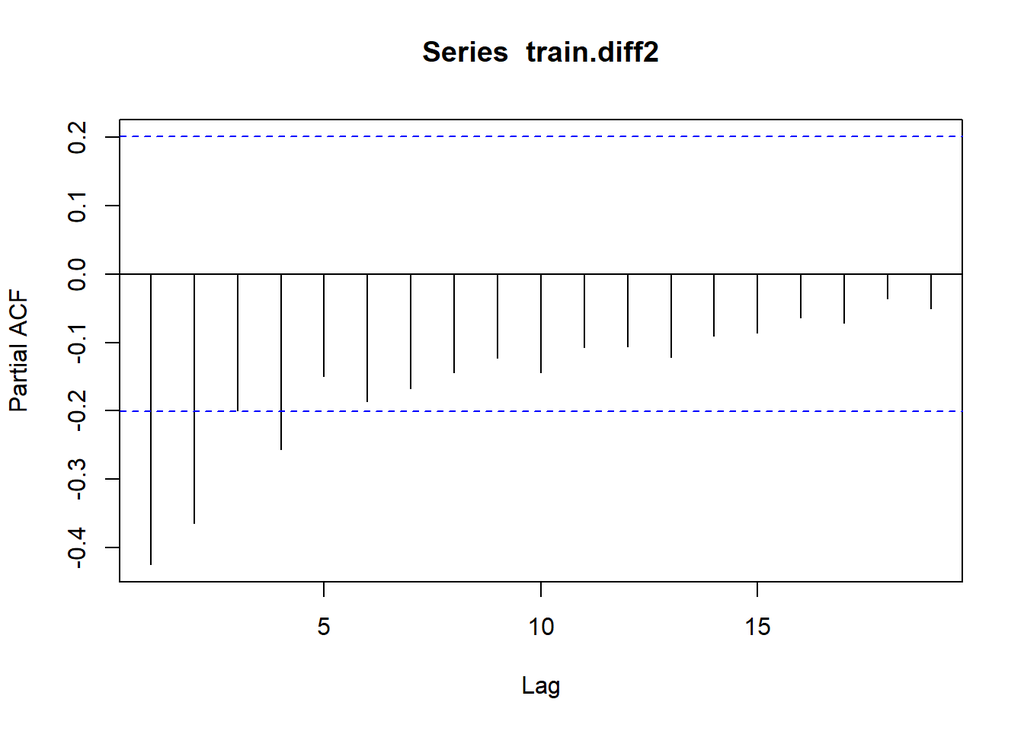

```r
pacf(train.diff2)
```

Berdasarkan plot tersebut, terlihat bahwa plot PACF cenderung *cuts off* pada lag ke 4, sehingga jika plot ACF dianggap *tails of*, maka model tentatifnya adalah ARIMA(4,2,0).

Jika baik plot ACF maupun plot PACF keduanya dianggap *tails of*, maka model yang terbentuk adalah ARIMA(4,2,1)

### Plot EACF

```r
eacf(train.diff2)
```

```
## AR/MA
##   0 1 2 3 4 5 6 7 8 9 10 11 12 13
## 0 x o o o o o o o o o o  o  o  o
## 1 x x o o o o o o o o o  o  o  o
## 2 x x o o o o o o o o o  o  o  o
## 3 x x x o o o o o o o o  o  o  o
## 4 x x x o o o o o o o o  o  o  o
## 5 x x x o o x o o o o o  o  o  o
## 6 x o o x x o o o o o o  o  o  o
## 7 x o o o x o o o o o o  o  o  o
```

Identifikasi model menggunakan plot EACF dilakukan dengan melihat ujung segitiga pada pola segitiga nol. Dalam hal ini model tentatif yang terbentuk adalah ARIMA(0,2,1), ARIMA(0,2,2), ARIMA(0,2,3), ARIMA(1,2,2) dan ARIMA(2,2,2).

## Pendugaan Parameter Model Tentatif

### ARIMA(0,2,1)

```r
model1.da=Arima(train.diff2, order=c(0,2,1),method="ML")
summary(model1.da)
```

```
## Series: train.diff2
## ARIMA(0,2,1)
##
## Coefficients:
##           ma1
##       -1.0000
## s.e.   0.0264
##
## sigma^2 = 7.397:  log likelihood = -226.78
## AIC=457.56   AICc=457.69   BIC=462.62
##
## Training set error measures:
##                         ME     RMSE       MAE MPE MAPE      MASE       ACF1
## Training set -0.0005816176 2.676378 0.8391679 NaN  Inf 0.9872563 -0.6069899
```

```r
lmtest::coeftest(model1.da)
```

```
##
## z test of coefficients:
##
##      Estimate Std. Error z value  Pr(>|z|)
## ma1 -0.999999   0.026381 -37.906 < 2.2e-16 ***
## ---
## Signif. codes:  0 '***' 0.001 '**' 0.01 '*' 0.05 '.' 0.1 ' ' 1
```

Pada model tentatif ARIMA (0,2,1) didapatkan nilai AIC sebesar 457.56 dan seluruh parameter signifikan

### ARIMA(0,2,2)

```r
model2.da=Arima(train.diff2, order=c(0,2,2),method="ML")
summary(model2.da)
```

```
## Series: train.diff2
## ARIMA(0,2,2)
##
## Coefficients:
##           ma1     ma2
##       -1.9894  1.0000
## s.e.   0.0412  0.0378
##
## sigma^2 = 2.654:  log likelihood = -182.48
## AIC=370.96   AICc=371.23   BIC=378.55
##
## Training set error measures:
##                        ME     RMSE       MAE MPE MAPE      MASE       ACF1
## Training set -0.004866394 1.594499 0.4587592 NaN  Inf 0.5397167 -0.4196222
```

```r
lmtest::coeftest(model2.da)
```

```
##
## z test of coefficients:
##
##      Estimate Std. Error z value  Pr(>|z|)
## ma1 -1.989446   0.041153 -48.342 < 2.2e-16 ***
## ma2  0.999989   0.037794  26.459 < 2.2e-16 ***
## ---
## Signif. codes:  0 '***' 0.001 '**' 0.01 '*' 0.05 '.' 0.1 ' ' 1
```

Pada model tentatif ARIMA (0,2,2) didapatkan nilai AIC sebesar 370.96 dan seluruh parameter signifikan

### ARIMA(0,2,3)

```r
model3.da=Arima(train.diff2, order=c(0,2,3),method="ML")
summary(model3.da)
```

```
## Series: train.diff2
## ARIMA(0,2,3)
##
## Coefficients:
```

```
##           ma1     ma2      ma3
##       -2.9392  2.8902  -0.9509
## s.e.      NaN     NaN      NaN
##
## sigma^2 = 1.481:  log likelihood = -159.79
## AIC=327.57   AICc=328.03   BIC=337.7
##
## Training set error measures:
##                      ME     RMSE       MAE MPE MAPE      MASE       ACF1
## Training set -0.0433582 1.184506 0.3674127 NaN  Inf 0.4322503 0.04529444
```

```r
lmtest::coeftest(model3.da)
```

```
##
## z test of coefficients:
##
##     Estimate Std. Error z value Pr(>|z|)
## ma1 -2.93921        NaN     NaN      NaN
## ma2  2.89020        NaN     NaN      NaN
## ma3 -0.95089        NaN     NaN      NaN
```

Pada model tentatif ARIMA (0,2,3) didapatkan nilai AIC sebesar 327.57 dan tidak ada parameter yang signifikan/cocok

### ARIMA(1,2,2)

```r
model4.da=Arima(train.diff2, order=c(1,2,2),method="ML")
summary(model4.da)
```

```
## Series: train.diff2
## ARIMA(1,2,2)
##
## Coefficients:
##           ar1      ma1     ma2
##       -0.4053  -1.9928  0.9999
## s.e.   0.0940   0.0394  0.0386
##
## sigma^2 = 2.199:  log likelihood = -174.17
## AIC=356.34   AICc=356.79   BIC=366.47
##
## Training set error measures:
##                        ME     RMSE       MAE MPE MAPE      MASE      ACF1
## Training set -0.007213465 1.443402 0.4253123 NaN  Inf 0.5003674 -0.162154
```

```r
lmtest::coeftest(model4.da)
```

```
##
## z test of coefficients:
##
##      Estimate Std. Error  z value  Pr(>|z|)
## ar1 -0.405315   0.093981  -4.3127 1.612e-05 ***
## ma1 -1.992841   0.039403 -50.5759 < 2.2e-16 ***
## ma2  0.999914   0.038595  25.9078 < 2.2e-16 ***
## ---
## Signif. codes:  0 '***' 0.001 '**' 0.01 '*' 0.05 '.' 0.1 ' ' 1
```

Pada model tentatif ARIMA (1,2,2) didapatkan nilai AIC sebesar 356.34 dan seluruh parameter signifikan

### ARIMA(2,2,2)

```r
model5.da=Arima(train.diff2, order=c(2,2,2),method="ML")
summary(model5.da)
```

```
## Series: train.diff2
## ARIMA(2,2,2)
##
## Coefficients:
##           ar1      ar2      ma1     ma2
##       -0.5553  -0.3401  -1.9943  1.0000
## s.e.   0.0972   0.0963   0.0404  0.0398
##
## sigma^2 = 1.931:  log likelihood = -168.43
## AIC=346.85   AICc=347.54   BIC=359.52
##
## Training set error measures:
##                       ME    RMSE       MAE MPE MAPE     MASE        ACF1
## Training set -0.01348284 1.34485 0.4204856 NaN  Inf 0.494689 -0.08569263
```

```r
lmtest::coeftest(model5.da)
```

```
##
## z test of coefficients:
##
##      Estimate Std. Error  z value  Pr(>|z|)
## ar1 -0.555331   0.097205  -5.7130  1.11e-08 ***
## ar2 -0.340104   0.096251  -3.5335 0.0004101 ***
## ma1 -1.994318   0.040407 -49.3556 < 2.2e-16 ***
## ma2  0.999985   0.039768  25.1453 < 2.2e-16 ***
## ---
## Signif. codes:  0 '***' 0.001 '**' 0.01 '*' 0.05 '.' 0.1 ' ' 1
```

Pada model tentatif ARIMA (2,2,2) didapatkan nilai AIC sebesar 346.85 dan seluruh parameter signifikan.

## Analisis Sisaan

Model terbaik hasil identifikasi kemudian dicek asumsi sisaannya. Sisaan model ARIMA harus memenuhi asumsi normalitas, kebebasan sisaan, dan kehomogenan ragam. Diagnostik model dilakukan secara eksplorasi dan uji formal.

### Eksplorasi Sisaan

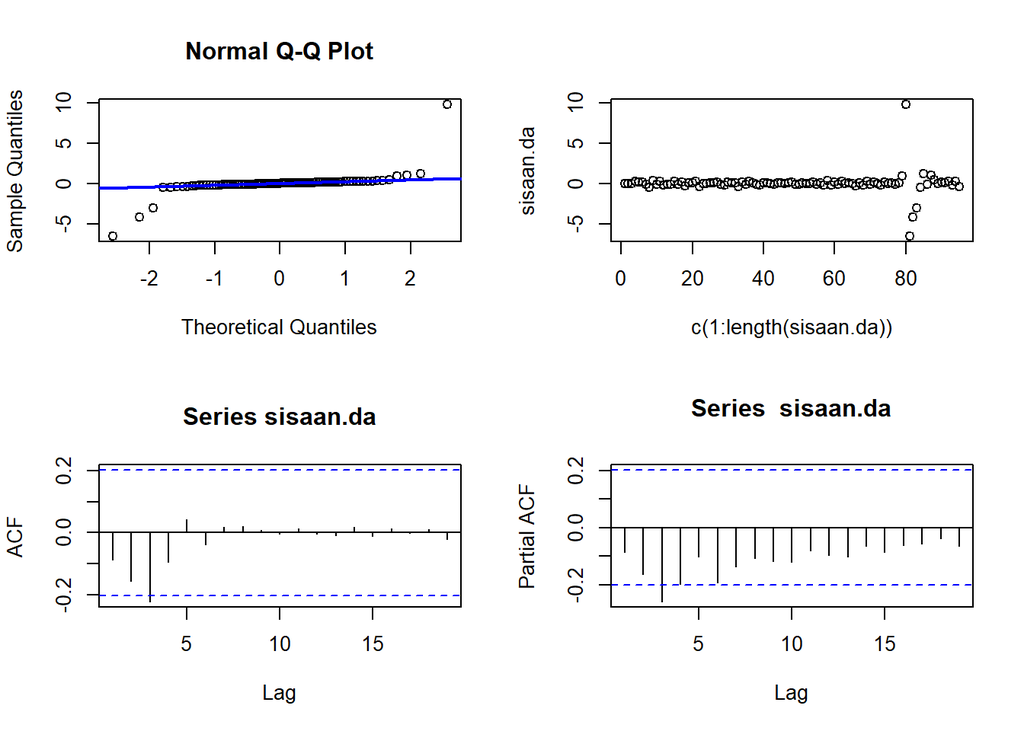

```r
#Eksplorasi
sisaan.da <- model5.da$residuals
par(mfrow=c(2,2))
qqnorm(sisaan.da)
qqline(sisaan.da, col = "blue", lwd = 2)
plot(c(1:length(sisaan.da)),sisaan.da)
acf(sisaan.da)
pacf(sisaan.da)
```

```r
par(mfrow = c(1,1))
```

### Uji Formal

```r
#1) Sisaan Menyebar Normal
ks.test(sisaan.da,"pnorm")
```

```
##
##  Exact one-sample Kolmogorov-Smirnov test
##
## data:  sisaan.da
## D = 0.31719, p-value = 5.353e-09
## alternative hypothesis: two-sided
```

Selain dengan eksplorasi, asumsi tersebut dapat diuji menggunakan uji formal. Pada tahapan ini uji formal yang digunakan untuk normalitas adalah uji Kolmogorov-Smirnov (KS). Hipotesis pada uji KS adalah sebagai berikut.

*Hipotesis :*

$H_0$ : Sisaan menyebar normal

$H_1$ : Sisaan tidak menyebar normal

Berdasarkan uji KS tersebut, didapat *p-value* sebesar 5.353e-09 < 0.05 sehingga tolak $H_0$ pada taraf nyata 5% dan menandakan bahwa sisaan tidak menyebar normal.Hasil ini berbeda dengan hasil eksplorasi menggunakan plot.

```r
#2) Sisaan saling bebas/tidak ada autokorelasi
Box.test(sisaan.da, type = "Ljung")
```

```
##
##  Box-Ljung test
##
## data:  sisaan.da
## X-squared = 0.71987, df = 1, p-value = 0.3962
```

Selanjutnya akan dilakukan uji formal untuk kebebasan sisaan menggunakan uji Ljung-Box. Hipotesis yang digunakan adalah sebagai berikut.

*Hipotesis :*

$H_0$ : Sisaan saling bebas

$H_1$ : Sisaan tidak tidak saling bebas

Berdasarkan uji Ljung-Box tersebut, didapat *p-value* sebesar 0.3962 > 0.05 sehingga tak tolak $H_0$ pada taraf nyata 5% dan menandakan bahwa sisaan saling bebas.Hasil ini berbeda dengan hasil eksplorasi menggunakan plot.

```r
#3) Sisaan homogen
Box.test((sisaan.da)^2, type = "Ljung")
```

```
##
##  Box-Ljung test
##
## data:  (sisaan.da)^2
## X-squared = 18.34, df = 1, p-value = 1.848e-05
```

Hipotesis yang digunakan untuk uji kehomogenan ragam adalah sebagai berikut.

*Hipotesis :*

$H_0$ : Ragam sisaan homogen

$H_1$ : Ragam sisaan tidak homogen

Berdasarkan uji Ljung-Box terhadap sisaan kuadrat tersebut, didapat *p-value* sebesar 1.848e-05 < 0.05 sehingga tolak $H_0$ pada taraf nyata 5% dan menandakan bahwa ragam sisaan tidak homogen.

```r
#4) Nilai tengah sisaan sama dengan nol
t.test(sisaan.da, mu = 0, conf.level = 0.95)
```

```
##
##  One Sample t-test
##
## data:  sisaan.da
## t = -0.097206, df = 94, p-value = 0.9228
## alternative hypothesis: true mean is not equal to 0
## 95 percent confidence interval:
##  -0.2888822  0.2619166
## sample estimates:
##   mean of x
## -0.01348284
```

Terakhir, dengan uji-t, akan dicek apakah nilai tengah sisaan sama dengan nol. Hipotesis yang diujikan sebagai berikut.

*Hipotesis :*

$H_0$ : nilai tengah sisaan sama dengan 0

$H_1$ : nilai tengah sisaan tidak sama dengan 0

Berdasarkan uji-ttersebut, didapat *p-value* sebesar 0.9228 > 0.05 sehingga tak tolak $H_0$ pada taraf nyata 5% dan menandakan bahwa nilai tengah sisaan sama dengan nol.

## Overfitting

Tahapan selanjutnya adalah *overfitting* dilakukan dengan menaikkan orde AR(p) dan MA(q) dari model ARIMA(2,2,2) untuk melihat apakah terdapat model lain yang lebih baik dari model saat ini. Kandidat model *overfitting* adalah ARIMA(3,2,2) dan ARIMA (2,2,3)

```r
#---OVERFITTING---#
model1.ov=Arima(train.diff2, order=c(3,2,2),method="ML")
summary(model1.ov)
```

```
## Series: train.diff2
## ARIMA(3,2,2)
##
## Coefficients:
##           ar1      ar2      ar3      ma1     ma2
##       -0.6225  -0.4437  -0.1733  -1.9951  1.0000
## s.e.   0.1028   0.1118   0.1012   0.0410  0.0404
##
## sigma^2 = 1.875:  log likelihood = -167
## AIC=346   AICc=346.97   BIC=361.19
##
## Training set error measures:
##                       ME     RMSE       MAE MPE MAPE      MASE        ACF1
## Training set -0.01420521 1.317805 0.4211248 NaN  Inf 0.4954409 -0.06759831
```

```r
lmtest::coeftest(model1.ov)
```

```
##
## z test of coefficients:
##
##      Estimate Std. Error  z value  Pr(>|z|)
## ar1 -0.622496   0.102849  -6.0525 1.426e-09 ***
## ar2 -0.443715   0.111790  -3.9692 7.212e-05 ***
## ar3 -0.173282   0.101162  -1.7129   0.08673 .
## ma1 -1.995133   0.041006 -48.6542 < 2.2e-16 ***
## ma2  0.999981   0.040426  24.7360 < 2.2e-16 ***
## ---
## Signif. codes:  0 '***' 0.001 '**' 0.01 '*' 0.05 '.' 0.1 ' ' 1
```

```r
model2.ov=Arima(train.diff2, order=c(2,2,3),method="ML")
summary(model2.ov)
```

```
## Series: train.diff2
## ARIMA(2,2,3)
##
## Coefficients:
```

```
##          ar1      ar2      ma1     ma2      ma3
##       0.0797  -0.0488  -2.9391  2.8906  -0.9514
## s.e.  0.1191   0.1118      NaN     NaN      NaN
##
## sigma^2 = 1.504:  log likelihood = -159.29
## AIC=330.58   AICc=331.55   BIC=345.77
##
## Training set error measures:
##                       ME     RMSE       MAE MPE MAPE      MASE        ACF1
## Training set -0.04321875 1.180135 0.3694579 NaN  Inf 0.4346564 -0.02670707
```

```r
lmtest::coeftest(model2.ov)
```

```
##
## z test of coefficients:
##
##      Estimate Std. Error z value Pr(>|z|)
## ar1  0.079673   0.119054  0.6692   0.5034
## ar2 -0.048831   0.111760 -0.4369   0.6622
## ma1 -2.939090        NaN     NaN      NaN
## ma2  2.890551        NaN     NaN      NaN
## ma3 -0.951354        NaN     NaN      NaN
```

Pada model overfitting ARIMA (3,2,2) didapatkan nilai AIC sebesar 346 namun terdapat parameter yang tidak signifikan sedangkan pada model overfitting ARIMA (2,2,3) didapatkan nilai AIC sebesar 330.58 namun tidak ada parameter yang signifikan/cocok.

## Peramalan

Setelah dibandingkan dari model tentatif dan model overfitting didapatkan nilai AIC terkecil dengan seluruh parameter yang signifikan adalah model ARIMA (2,2,2). Sehingga pada proses peramalan akan dilakukan menggunakan model ARIMA (2,2,2). Peramalan dilakukan menggunakan fungsi `forecast()` . Contoh peramalan berikut ini dilakukan untuk 24 hari ke depan.

```r
#---FORECAST---#
ramalan.da <- forecast::forecast(model5.da, h = 24)
ramalan.da
```

```
##     Point Forecast     Lo 80    Hi 80     Lo 95    Hi 95
##  98   0.1587063826 -1.639767 1.957180 -2.591822 2.909235
##  99   0.0722848871 -1.962936 2.107506 -3.040318 3.184887
## 100  -0.1429540435 -2.178332 1.892424 -3.255797 2.969889
## 101   0.0007745271 -2.074529 2.076078 -3.173128 3.174677
## 102  -0.0110312321 -2.090983 2.068921 -3.192043 3.169981
## 103  -0.0585502466 -2.138664 2.021564 -3.239810 3.122709
## 104  -0.0333387747 -2.117503 2.050825 -3.220792 3.154115
## 105  -0.0363705514 -2.120697 2.047956 -3.224073 3.151332
## 106  -0.0484539061 -2.133616 2.036708 -3.237434 3.140526
## 107  -0.0459050052 -2.132858 2.041048 -3.237624 3.145814
## 108  -0.0484033670 -2.136545 2.039738 -3.241940 3.145133
## 109  -0.0530753158 -2.142761 2.036611 -3.248974 3.142824
## 110  -0.0548236119 -2.146472 2.036825 -3.253724 3.144076
## 111  -0.0574562564 -2.151118 2.036206 -3.259436 3.144523
## 112  -0.0605921407 -2.156541 2.035357 -3.266070 3.144885
## 113  -0.0631477903 -2.161692 2.035396 -3.272594 3.146298
## 114  -0.0658545082 -2.167223 2.035513 -3.279620 3.147911
## 115  -0.0686746732 -2.173153 2.035804 -3.287197 3.149848
## 116  -0.0713804587 -2.179277 2.036516 -3.295130 3.152369
## 117  -0.0741111789 -2.185722 2.037500 -3.303542 3.155319
## 118  -0.0768669530 -2.192512 2.038778 -3.312466 3.158732
## 119  -0.0796003334 -2.199611 2.040410 -3.321877 3.162676
## 120  -0.0823376288 -2.207053 2.042378 -3.331810 3.167135
## 121  -0.0850803663 -2.214853 2.044692 -3.342287 3.172126
```

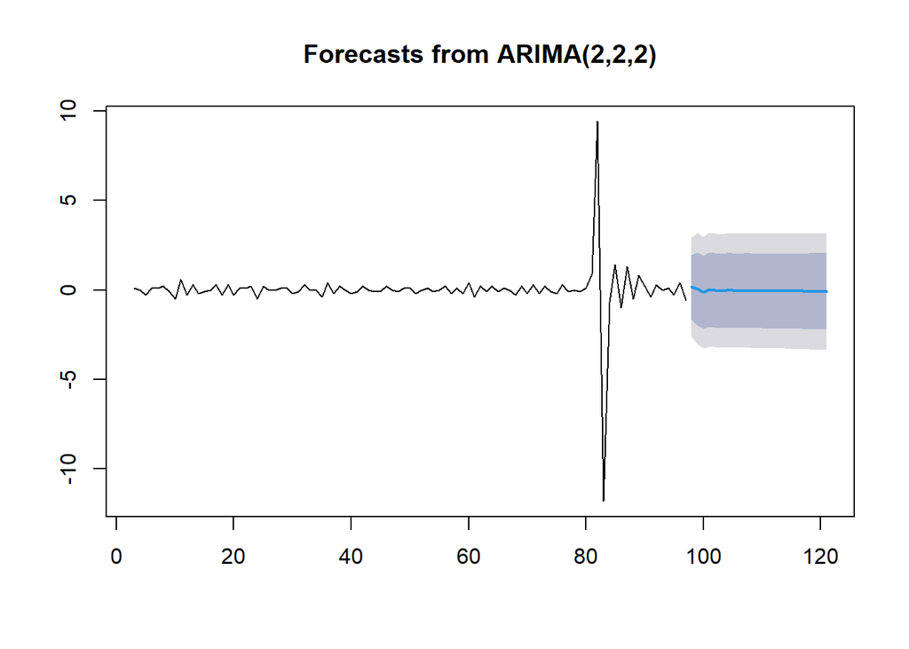

```r
data.ramalan.da <- ramalan.da$mean
plot(ramalan.da)
```

Berdasarkan hasil plot ramalan di atas, dapat dilihat bahwa ramalan ARIMA(2,2,2) cenderung stabil hingga akhir periode. Selanjutnya, dapat dicari nilai akurasi antara hasil ramalan dengan data uji sebagai berikut.

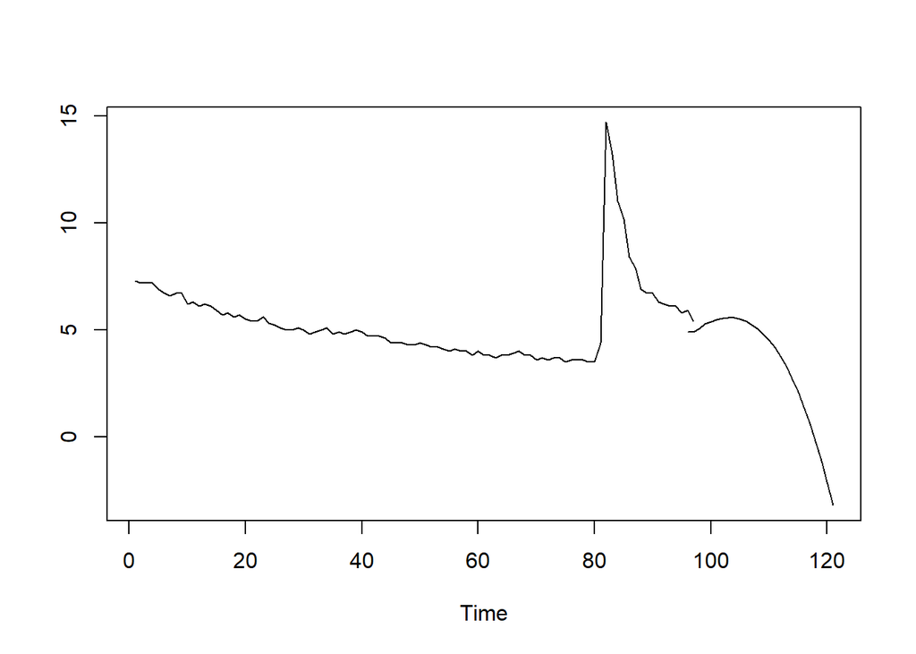

```r
pt_1 <- train.ts[97] # nilai akhir data latih
pt_2 <- train.ts[96] # nilai data latih 2 dari akhir
hasil.forc.Diff <- data.ramalan.da
hasil <- diffinv(hasil.forc.Diff, differences = 2) + 2 * pt_1 - pt_2

ts.plot(train.ts, hasil)
```

```r
perbandingan.da <- matrix(data = c(head(test.ts, n = 24), hasil[-c(1, 2)]),
                         nrow = 24, ncol = 2)
colnames(perbandingan.da) <- c("Aktual", "Hasil Forecast")
perbandingan.da
```

```
##       Aktual Hasil Forecast
##  [1,]    5.2      5.0587064
##  [2,]    4.8      5.2896977
##  [3,]    4.5      5.3777349
##  [4,]    4.2      5.4665466
##  [5,]    3.9      5.5443272
##  [6,]    4.0      5.5635574
##  [7,]    3.8      5.5494489
##  [8,]    3.6      5.4989699
##  [9,]    3.6      5.4000369
## [10,]    3.6      5.2551990
## [11,]    3.6      5.0619576
## [12,]    3.5      4.8156410
## [13,]    3.7      4.5145007
## [14,]    3.5      4.1559042
## [15,]    3.7      3.7367156
## [16,]    3.6      3.2543791
## [17,]    3.5      2.7061882
## [18,]    3.4      2.0893225
## [19,]    3.6      1.4010764
## [20,]    3.5      0.6387192
## [21,]    3.4     -0.2005050
## [22,]    3.7     -1.1193296
## [23,]    3.6     -2.1204918
## [24,]    3.5     -3.2067343
```

```r
accuracy(ts( hasil[-c(1, 2)]), head(test.ts, n = 24))
```

```
##                ME     RMSE      MAE      MPE     MAPE      ACF1 Theil's U
## Test set 0.469518 2.539489 1.905371 14.46777 52.45327 0.8450533  15.10102
```